# RSV (ABRYSVO) - Exposure during pregnancy

OpenSourcePV

Data Lock Point: Data contains VAERS reports processed as of 2023_11_24 (Year_Month_Day). Flag NEW was defined against reports processed as of 2023_10_27.

# 1 Quantitative Signal status

## 1.1 Disproportionality

The vaccine-event combination “RSV (ABRYSVO) - Exposure during pregnancy” was **a signal of disproportionate reporting** with an EB05 value of 2.43.

The threshold for being flagged as a signal of disproportionate reporting is an EB05>=2 meaning that there there is a 95% probability that the reporting of Exposure during pregnancy was at least twice post exposure to RSV (ABRYSVO) than post all vaccines. Under the assumption of no causality between RSV (ABRYSVO) and Exposure during pregnancy and no bias it would have been expected to observe an EBGM of 1.

It means that the quantified causality criterion of strength of association is **met**.

*It is to be noted that the nature of the spontaneous report does not provide reliable estimates of the strength of association (whatever the choice of the disproportionality method) and that some reporting bias or difference in demographic characteristics might explain the (un)observed disproportion*.

## 1.2 Time-to-onset

The vaccine-event combination “RSV (ABRYSVO) - Exposure during pregnancy” was **not a signal of unexpected time-to-onset distribution** with a p-value of the two-sample Kolmogorov-Smirnov test being 0.299707 and distance between the two empirical cumulative distributions being of 26.044905%.

The threshold for being flagged as a signal of unexpected time-to-onset distribution is a P-value of the two-sample Kolmogorov-Smirnov test <0.001 and a distance between the two empirical distributions larger than 20%. Under the assumption of no causality and no bias, it would have been expected that the time-to-onset distribution for “Exposure during pregnancy” would have been the same post RSV (ABRYSVO) than post other vaccines. The two-sample Kolmogorov-Smirnov tests this hypothesis.

It means that the quantified causality criterion of temporality is **not met**.

*It is to be noted that the nature of the spontaneous report does not provide reliable estimates of the temporal relationship between the exposure and the occurrence of the events as there is the reporting bias over time: the latter the event occurs after exposure, the less chance it has to be reported. Other biases could distort the reported time-to-onset distribution (media attention, etc.)*

## 1.3 Overall

Based on the screening of the Empirical Bayes Geometric Mean (EBGM) and the screening of the time-to-onset distribution,the vaccine-event combination “RSV (ABRYSVO) - Exposure during pregnancy” is **considered as quantitative signal**.

# 2 Signal History

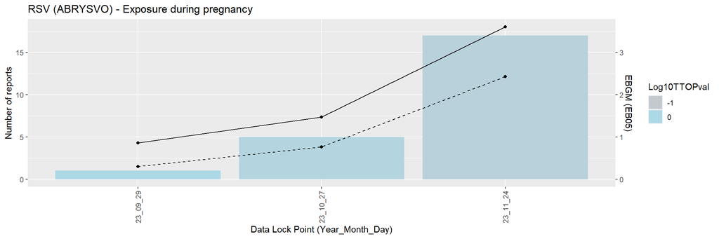

# 3 Case series

## 3.1 Seriousness

A total of 17 reports of Exposure during pregnancy were received post exposure to RSV (ABRYSVO). Among them:

- 0 (0.0 %) were fatal cases.
- 0 (0.0 %) were life threatening cases.
- 4 (23.5 %) were hospitalized cases.
- 0 (0.0 %) were emergency room cases.
- 0 (0.0 %) were cases with disabilies.

12 new cases were received since last data refresh.

## 3.2 Demographic characteristics

17 cases of Exposure during pregnancy post RSV (ABRYSVO) were reported in VAERS:

- Among them, there were 16 (94.1%) female cases and 0 (0%) male cases while the overall female:male ratio is 63:28%.
- The mean (median) age for patients presenting symptoms of Exposure during pregnancy was 32 (32) years while the overall mean (median) age was 71 (72) years.
- The top 5 contributing US states for patients presenting symptoms of Exposure during pregnancy were TX ( 17.6 %) , NA ( 17.6 %) , IN ( 11.8 %) , PA ( 11.8 %) , AZ ( 5.9 %) while overall the top 5 of contributing US states are NA ( 12.9 %) , FL ( 5.6 %) , OH ( 5.6 %) , NY ( 5.4 %) , CA ( 5.3 %)

# 4 Listing of the cases

Narratives can be made visible clicking on the ⊕ symbol.

|  | VAERS_ID | Sex/Age (Years) | Receipt Date | Seriousness status | List of symptoms | new | SYMPTOM_TEXT |
| --- | --- | --- | --- | --- | --- | --- | --- |
| &oplus; | 2684479 | F/35 | 09/21/2023 |  | Exposure during pregnancy, No adverse event | No | Medication error no adverse event RSV hasnt been approved by ACIP yet No adverse event Patient pregnant wk 33 |
| &oplus; | 2696141 | F/31 | 10/14/2023 |  | Exposure during pregnancy, Pain | No | Pregnant individual received a sterile injection in left arm Experienced localized pain |
| &oplus; | 2696249 | F/36 | 10/15/2023 |  | Cough, Exposure during pregnancy, Fatigue, Headache, Influenza, Nasopharyngitis, Oropharyngeal pain, Pain, Respiratory tract congestion, Rhinorrhoea | No | 34 weeks pregnant healthy due 11 22 23 Within hours experienced nasal drainage then within 24 hrs all the cold and flu symptoms except fever Body aches congestion drippy nose headache cough sore throa… |
| &oplus; | 2696411 | F/32 | 10/16/2023 |  | Exposure during pregnancy, No adverse event | No | Patient was 32 weeks pregnant at the time of vaccination Prescription was sent by patients MD and pharmacist administered the vaccine At the time of vaccination according to state law the patient was … |
| &oplus; | 2699929 | F/25 | 10/22/2023 | Hospitalized | Exposure during pregnancy, Premature delivery, Premature labour, Twin pregnancy | No | Pre term delivery Pregnancy with di di twins no complications noted throughout pregnancy Water broke and labor started day after vaccine given Was set to deliver 38w2d on November 21 2023 Delivered at… |
| &oplus; | 2705315 | F/33 | 10/28/2023 |  | Blood pressure increased, Exposure during pregnancy | Yes | Healthy pregnancy no complications 36 weeks at time of administration due date 11 18 2023 and no birth weight baby isn t born Starting 10 22 23 my blood pressure went from 112 73 or lower throughout b… |
| &oplus; | 2705353 | F/39 | 10/28/2023 |  | Dizziness, Dyspnoea, Exposure during pregnancy, Loss of consciousness, Palpitations, Visual impairment | Yes | 35 weeks pregnant about 20 hours after receiving dose I had vision issues bright lights blacking out dizziness feeling of racing heart and shortness of breath |
| &oplus; | 2709334 | F/32 | 11/03/2023 |  | Exposure during pregnancy, Injection site erythema, Nausea | Yes | Patient received vaccine at 36 w gestation EDD 11 28 2023 within 24 h after vaccine developed nausea and erythema to left arm at injection site persisting 48h after vaccination without history of reac… |
| &oplus; | 2712004 | F/37 | 11/09/2023 | Hospitalized | Exposure during pregnancy, Premature delivery, Premature labour | Yes | I was 35 w 6 d pregnant The following day I started with contractions and I delivered on early days after receiving vaccine Delivered at 36 w 1 d Birth weight 6 lbs 2 oz Estimated date of delivery was… |
| &oplus; | 2712615 | F/NA | 11/10/2023 |  | Exposure during pregnancy, Premature delivery | Yes | mother received Abrysvo This is a spontaneous report received from contactable reporters Physician from medical information team An adult female patient pregnant received rsv vaccine protsubunit pref … |

[output cut: 7 more lines]

# 5 Disclaimer

This analysis is exploratory only and authors cannot be held responsible for any decision made using these data. It is important to distinguish quantitative signals such as disproportionate reporting, unexpected time-to-onset patterns or cluster from safety signals. Only a qualitative review using multiple data source (literature, clinical trials, etc.) and multiple causality criteria assessment could qualify quantitative signals into safety signals.